# Desafio - Semantix

## Definições

- Dados relacionados com campanha de marketing direto de uma instituição bancária.
- As campanhas de marketing foram baseadas em chamadas telefônicas.
- Contatavam o cliente mais de uma vez para acessar se o produto (depósito a prazo bancário) seria aceito ou não.

## Variáveis

Input:

- Informações sobre o cliente
  1. idade (numérica)
  2. emprego: tipo de emprego
  3. estado civil (levando em consideração que “divorciado”" significa divorciado ou viúvo)
  4. educação
  5. tem crédito?
  6. saldo médio anual
  7. tem empréstimo imobiliário?
  8. tem empréstimo pessoal?
- Informações sobre o último contato da campanha atual:
  9. contato
  10. último dia de contato no mês
  11. mês do último contato do ano
  12. duração do último contato em segundos
  13. número de contatos realizados durante esta campanha
  14. número de dias que passaram depois que o cliente foi contatado pela última vez de uma campanha anterior (-1 significa que o cliente não foi contatado anteriormente)
  15. número de contatos realizados antes desta campanha
  16. resultado da campanha de marketing anterior

Output:

- Variável de interesse:
  17. o cliente assinou um depósito a prazo?

### Sumário dos dados

#### Público geral

```r
library(dplyr)
library(ggplot2)
library(party)
```

```r
desafioSemantix = read.csv('~/Documentos/desafio_ds/semantix/bank-full.csv', sep = ';')
```

```r
summary(desafioSemantix)
```

```
##       age                 job           marital          education
##  Min.   :18.00   blue-collar:9732   divorced: 5207   primary  : 6851
##  1st Qu.:33.00   management :9458   married :27214   secondary:23202
##  Median :39.00   technician :7597   single  :12790   tertiary :13301
##  Mean   :40.94   admin.     :5171                    unknown  : 1857
##  3rd Qu.:48.00   services   :4154
##  Max.   :95.00   retired    :2264
##                  (Other)    :6835
##  default        balance       housing      loan            contact
##  no :44396   Min.   : -8019   no :20081   no :37967   cellular :29285
##  yes:  815   1st Qu.:    72   yes:25130   yes: 7244   telephone: 2906
##              Median :   448                           unknown  :13020
##              Mean   :  1362
##              3rd Qu.:  1428
##              Max.   :102127
##
##       day            month          duration         campaign
##  Min.   : 1.00   may    :13766   Min.   :   0.0   Min.   : 1.000
##  1st Qu.: 8.00   jul    : 6895   1st Qu.: 103.0   1st Qu.: 1.000
##  Median :16.00   aug    : 6247   Median : 180.0   Median : 2.000
##  Mean   :15.81   jun    : 5341   Mean   : 258.2   Mean   : 2.764
##  3rd Qu.:21.00   nov    : 3970   3rd Qu.: 319.0   3rd Qu.: 3.000
##  Max.   :31.00   apr    : 2932   Max.   :4918.0   Max.   :63.000
##                  (Other): 6060
##      pdays          previous           poutcome       y
##  Min.   : -1.0   Min.   :  0.0000   failure: 4901   no :39922
##  1st Qu.: -1.0   1st Qu.:  0.0000   other  : 1840   yes: 5289
##  Median : -1.0   Median :  0.0000   success: 1511
##  Mean   : 40.2   Mean   :  0.5803   unknown:36959
##  3rd Qu.: -1.0   3rd Qu.:  0.0000
##  Max.   :871.0   Max.   :275.0000
##
```

Sumário dos dados:

#### Público que tiveram campanha anterior

```r
summary(desafioSemantix %>% filter(previous != 0) )
```

```
##       age                 job           marital         education
##  Min.   :18.00   management :1826   divorced: 931   primary  :1020
##  1st Qu.:33.00   blue-collar:1617   married :4745   secondary:4254
##  Median :38.00   technician :1342   single  :2581   tertiary :2660
##  Mean   :40.95   admin.     :1089                   unknown  : 323
##  3rd Qu.:48.00   services   : 706
##  Max.   :93.00   retired    : 488
##                  (Other)    :1189
##  default       balance      housing     loan           contact
##  no :8200   Min.   :-1884   no :3115   no :7134   cellular :7556
##  yes:  57   1st Qu.:  168   yes:5142   yes:1123   telephone: 631
##             Median :  602                         unknown  :  70
##             Mean   : 1557
##             3rd Qu.: 1743
##             Max.   :81204
##
##       day            month         duration         campaign
##  Min.   : 1.00   may    :2514   Min.   :   1.0   Min.   : 1.000
##  1st Qu.: 7.00   nov    :1150   1st Qu.: 113.0   1st Qu.: 1.000
##  Median :14.00   apr    :1118   Median : 193.0   Median : 2.000
##  Mean   :14.29   feb    : 924   Mean   : 260.1   Mean   : 2.056
##  3rd Qu.:20.00   aug    : 531   3rd Qu.: 324.0   3rd Qu.: 2.000
##  Max.   :31.00   jan    : 498   Max.   :2219.0   Max.   :16.000
##                  (Other):1522
##      pdays          previous          poutcome      y
##  Min.   :  1.0   Min.   :  1.000   failure:4901   no :6352
##  1st Qu.:133.0   1st Qu.:  1.000   other  :1840   yes:1905
##  Median :194.0   Median :  2.000   success:1511
##  Mean   :224.6   Mean   :  3.178   unknown:   5
##  3rd Qu.:327.0   3rd Qu.:  4.000
##  Max.   :871.0   Max.   :275.000
##
```

- Em média, número de dias que passaram depois que o cliente foi contatado pela última vez de uma campanha anterior é de aproximadamente 225 dias.
- Em média, número realizado de contatos foi de aproximadamente 3.
- O resultado da campanha teve maior proporção de falha.

#### Resposta das perguntas

1. Qual profissão tem mais tendência a fazer um empréstimo? De qual tipo?

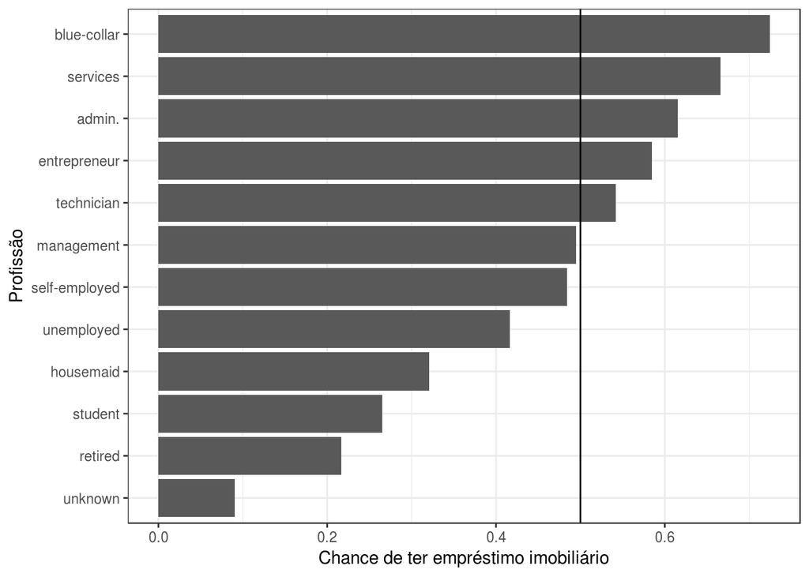

```r
as.data.frame(prop.table(table(desafioSemantix$job, desafioSemantix$housing), margin = 1)) %>%
  filter(Var2 == 'yes') %>%
  ggplot(aes(x = reorder(Var1, Freq), y = Freq)) +
  xlab('Profissão') +
  ylab('Chance de ter empréstimo imobiliário')+
  geom_bar(stat = 'identity') +
  geom_hline(yintercept = 0.5) +
  coord_flip() +
  theme_bw()
```

- ‘blue-collar’, ‘services’, ‘admin.’, ‘entrepeneur’ e ‘technician’ têm chance maior que 0,5 de converter em empréstimo imobiliário.
- ‘blue-collar’ é a profissão que mais tende a ter empréstimo imobiliário.

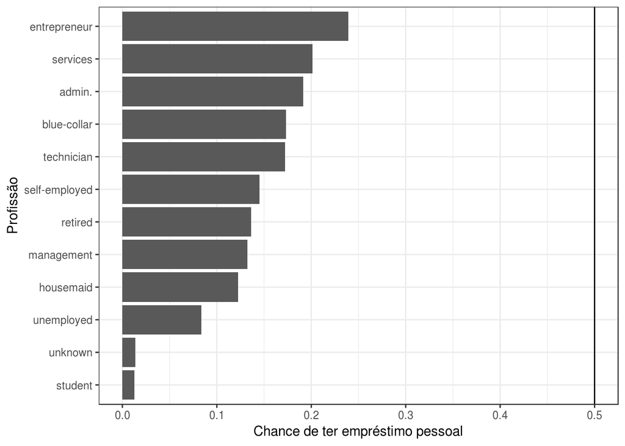

```r
as.data.frame(prop.table(table(desafioSemantix$job, desafioSemantix$loan), margin = 1) )  %>%
  filter(Var2 == 'yes') %>%
  ggplot(aes(x = reorder(Var1, Freq), y = Freq)) +
  xlab('Profissão') +
  ylab('Chance de ter empréstimo pessoal')+
  geom_bar(stat = 'identity') +
  geom_hline(yintercept = 0.5) +
  coord_flip() +
  theme_bw()
```

- Todas as profissões têm chances menor que 0,5 de ter empréstimo pessoal.
- Entre todas as profissões, ‘entrenepeur’ é a que apresenta mais chance de ter empréstimo pessoal.
2. Fazendo uma relação entre número de contatos e sucesso da campanha quais são os pontos relevantes a serem observados?

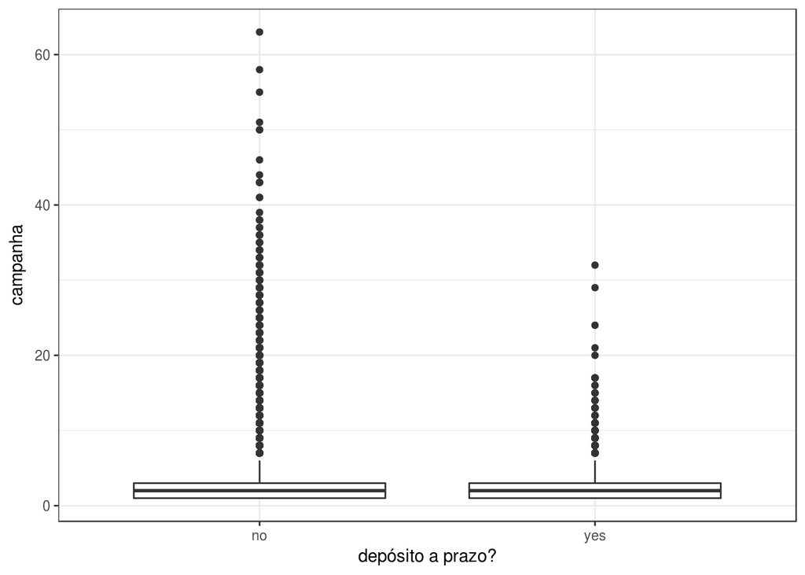

```r
desafioSemantix %>%
  ggplot(aes(x = y, y = campaign)) +
  geom_boxplot() +
  xlab('depósito a prazo?') +
  ylab('campanha') +
  theme_bw()
```

```r
desafioSemantix %>%
  group_by(y) %>%
  summarise(mean(campaign), sd(campaign),  median(campaign), max(campaign), quantile(campaign, probs = 0.25), quantile(campaign, probs = 0.75), quantile(campaign, probs = 0.99))
```

```
## # A tibble: 2 x 8
##   y     `mean(campaign)` `sd(campaign)` `median(campaig… `max(campaign)`
##   <fct>            <dbl>          <dbl>            <dbl>           <dbl>
## 1 no                2.85           3.21                2              63
## 2 yes               2.14           1.92                2              32
## # ... with 3 more variables: `quantile(campaign, probs = 0.25)` <dbl>,
## #   `quantile(campaign, probs = 0.75)` <dbl>, `quantile(campaign, probs =
## #   0.99)` <dbl>
```

- Os clientes que rejeitam o depósito a prazo apresentam máximo maior de contatos do que os que aceitam.
- O número médio de contatos adequado para adesão seria de 2 contatos.
- O número máximo de contatos adequado para adesão seria de 10 (99% dos clientes que foram aprovados tiveram até 10 contatos).
4. O resultado da campanha anterior tem relevância na campanha atual?

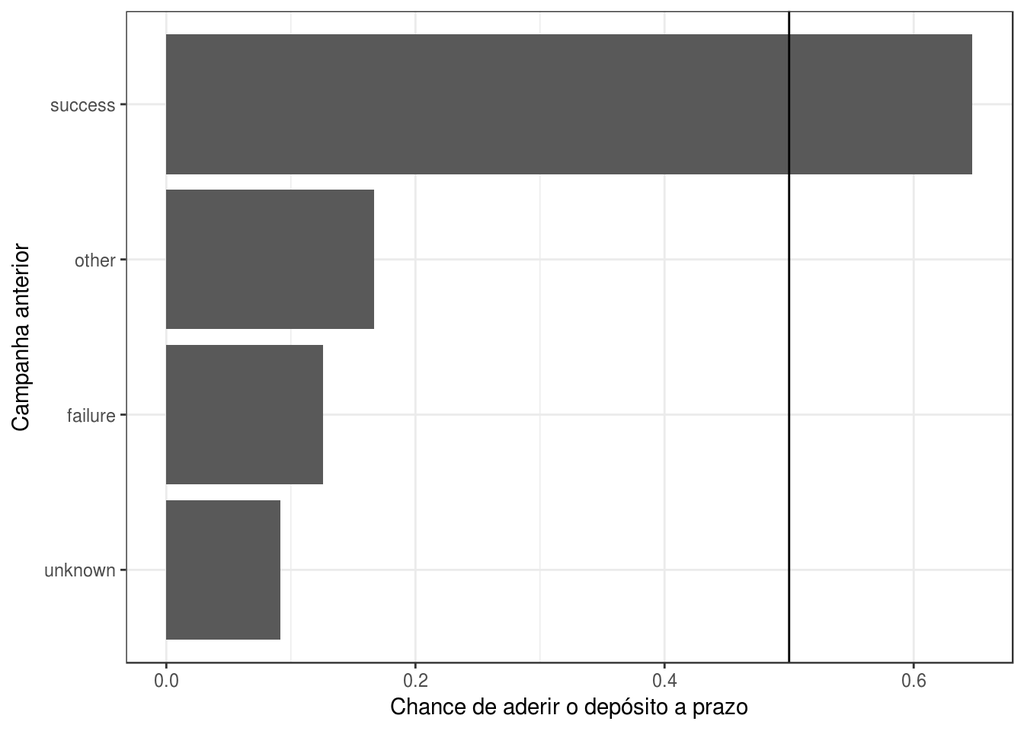

```r
as.data.frame(prop.table(table(desafioSemantix$poutcome, desafioSemantix$y), margin = 1)) %>%
    filter(Var2 == 'yes') %>%
    ggplot(aes(x = reorder(Var1, Freq), y = Freq)) +
    xlab('Campanha anterior') +
   ylab('Chance de aderir o depósito a prazo')+
  geom_bar(stat = 'identity') +
  geom_hline(yintercept = 0.5) +
  coord_flip() +
  theme_bw()
```

- Quando a campanha anterior foi um sucesso, a campanha atual terá mais chance de ser também.
5. Qual o fator determinante para que o banco exija um seguro de crédito?

```r
treeSeguroCredito = ctree(default ~ marital + job + age + balance + education + housing + loan, data = desafioSemantix)
```

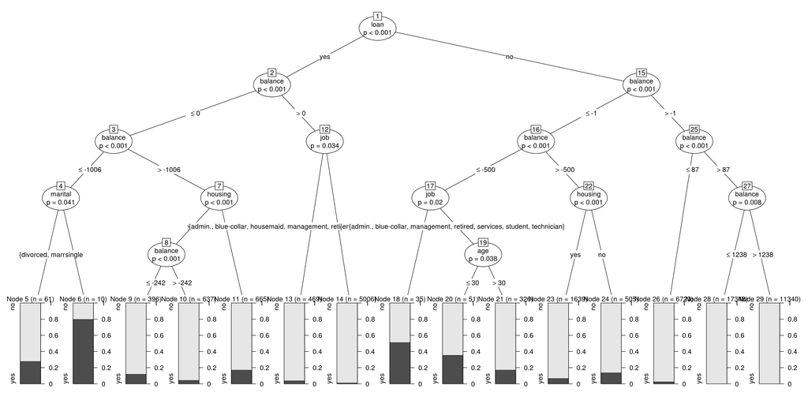

```r
plot(treeSeguroCredito)
```

- Pela árvore, verificamos que o ‘balance’ (saldo médio) é o fator que mais quebra pra definir a chance de dar seguro de crédito ou não, demonstrando ser a mais importante para impacto desta.

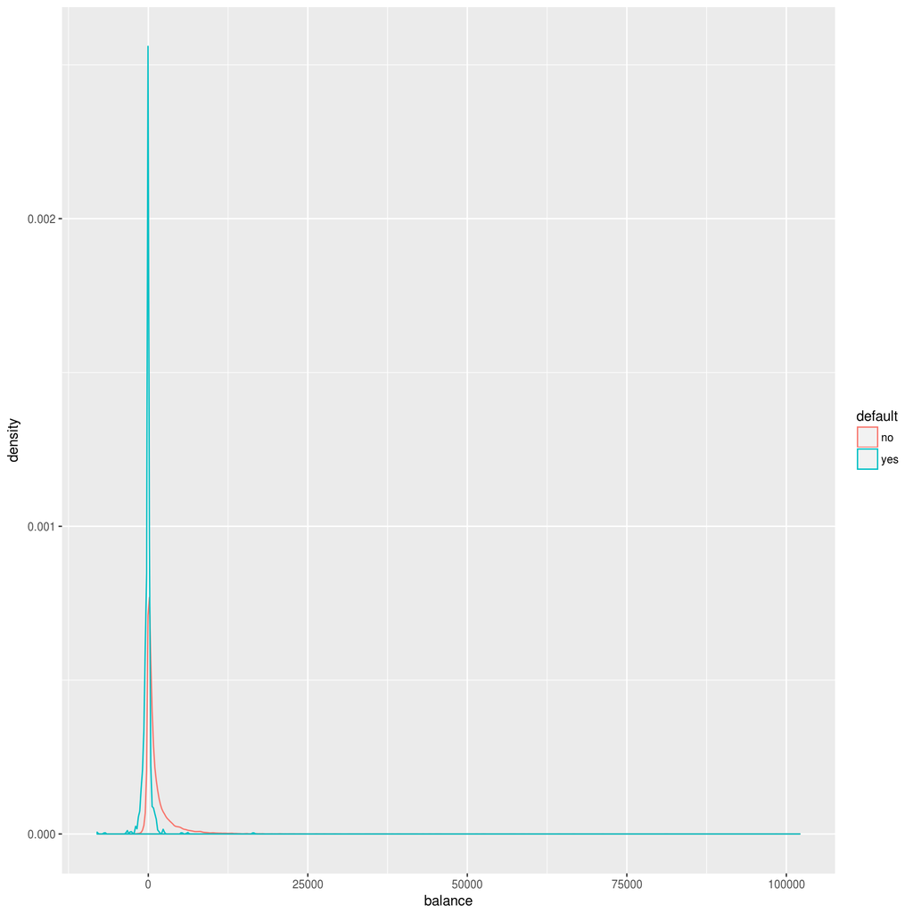

```r
desafioSemantix %>%
  ggplot(aes(group = default, x = balance, colour = default)) +
  geom_density()
```

```r
desafioSemantix %>%
  group_by(default) %>%
  summarise(mean(balance), median(balance), sd(balance))
```

```
## # A tibble: 2 x 4
##   default `mean(balance)` `median(balance)` `sd(balance)`
##   <fct>             <dbl>             <dbl>         <dbl>
## 1 no                1390.               468         3063.
## 2 yes               -138.                -7          907.
```

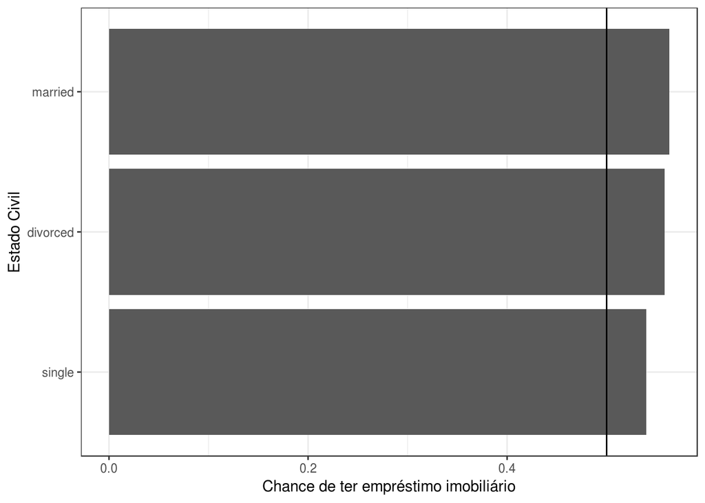

```r
as.data.frame(prop.table(table(desafioSemantix$marital, desafioSemantix$housing), margin = 1)) %>%
  filter(Var2 == 'yes') %>%
  ggplot(aes(x = reorder(Var1, Freq), y = Freq)) +
  xlab('Estado Civil') +
  ylab('Chance de ter empréstimo imobiliário')+
  geom_bar(stat = 'identity') +
  geom_hline(yintercept = 0.5) +
  coord_flip() +
  theme_bw()
```

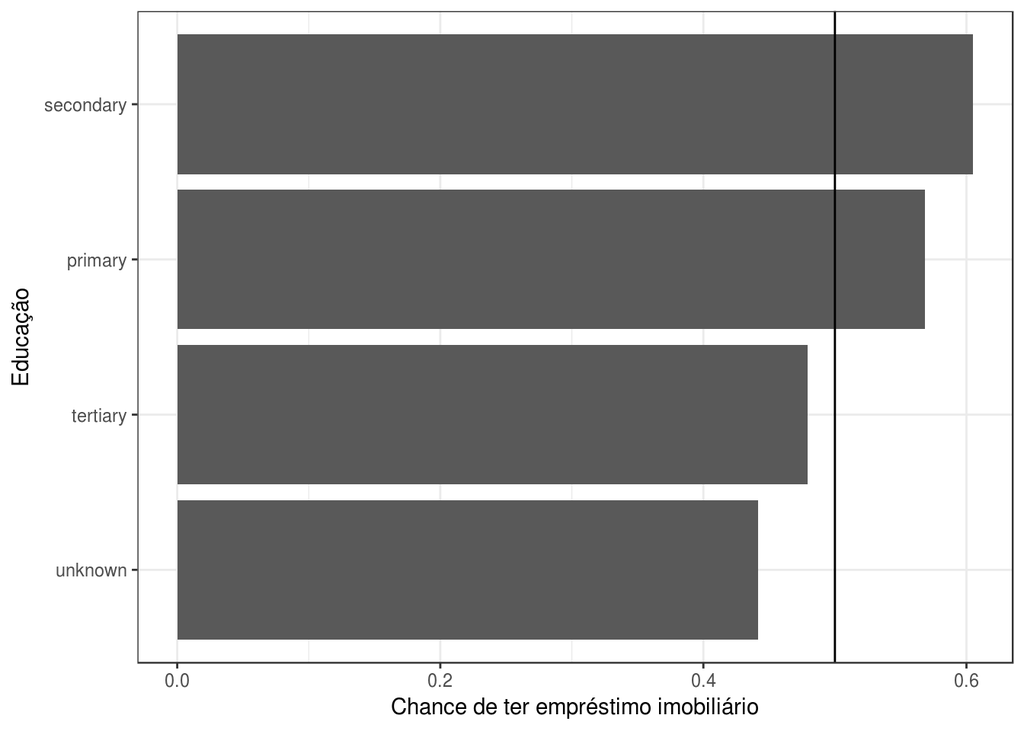

```r
as.data.frame(prop.table(table(desafioSemantix$education, desafioSemantix$housing), margin = 1)) %>%
  filter(Var2 == 'yes') %>%
  ggplot(aes(x = reorder(Var1, Freq), y = Freq)) +
  xlab('Educação') +
  ylab('Chance de ter empréstimo imobiliário')+
  geom_bar(stat = 'identity') +
  geom_hline(yintercept = 0.5) +
  coord_flip() +
  theme_bw()
```

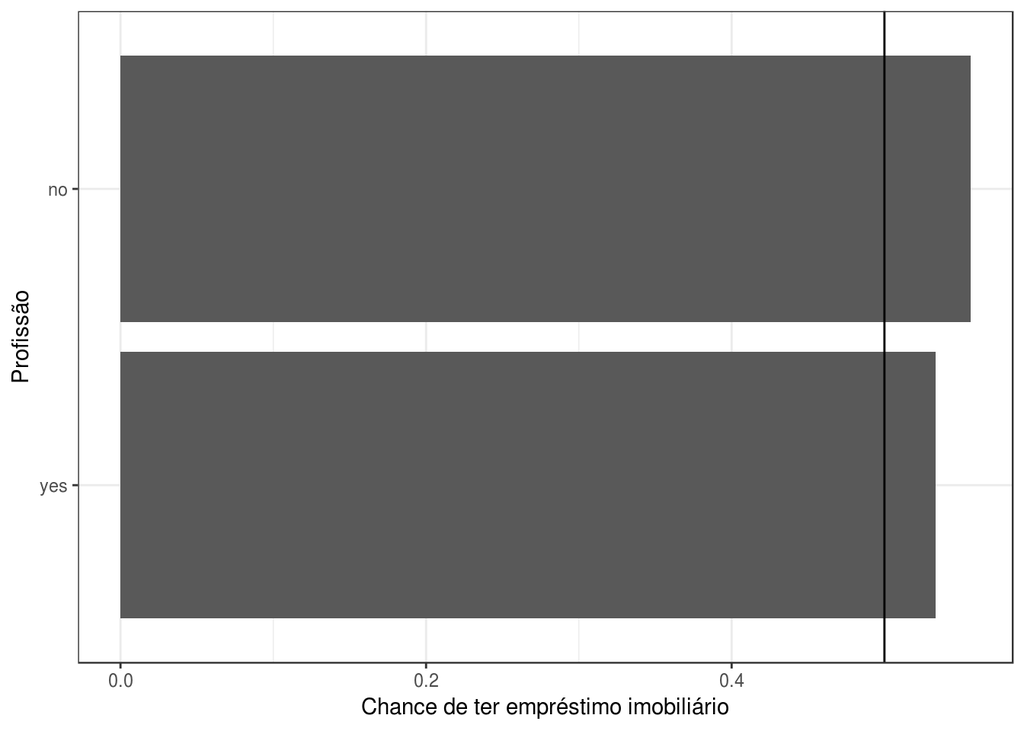

```r
as.data.frame(prop.table(table(desafioSemantix$default, desafioSemantix$housing), margin = 1)) %>%
  filter(Var2 == 'yes') %>%
  ggplot(aes(x = reorder(Var1, Freq), y = Freq)) +
  xlab('Profissão') +
  ylab('Chance de ter empréstimo imobiliário')+
  geom_bar(stat = 'identity') +
  geom_hline(yintercept = 0.5) +
  coord_flip() +
  theme_bw()
```

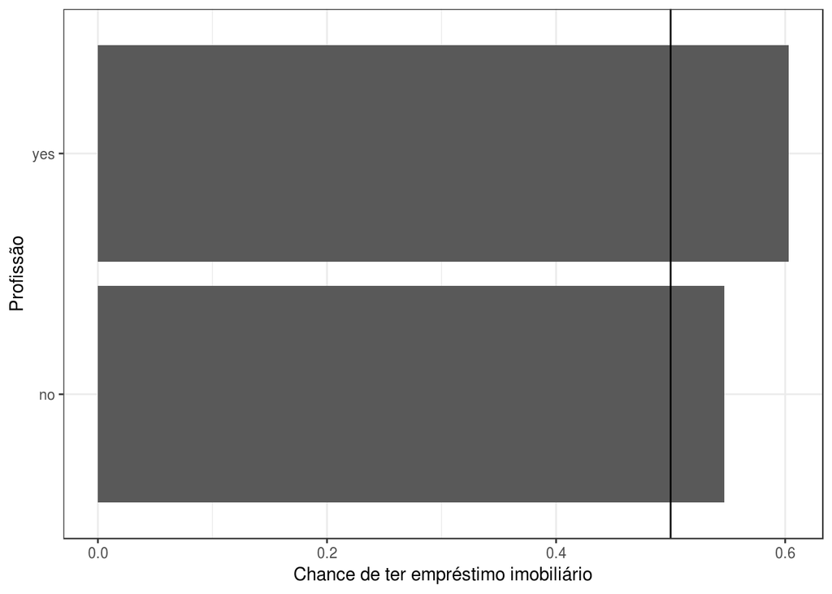

```r
as.data.frame(prop.table(table(desafioSemantix$loan, desafioSemantix$housing), margin = 1)) %>%
  filter(Var2 == 'yes') %>%
  ggplot(aes(x = reorder(Var1, Freq), y = Freq)) +
  xlab('Profissão') +
  ylab('Chance de ter empréstimo imobiliário')+
  geom_bar(stat = 'identity') +
  geom_hline(yintercept = 0.5) +
  coord_flip() +
  theme_bw()
```

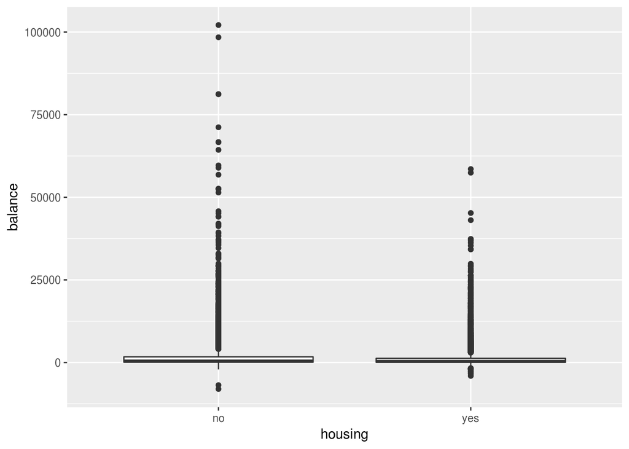

```r
desafioSemantix %>%
  ggplot(aes(x = housing, y = balance)) +
  geom_boxplot()
```

```r
desafioSemantix %>%
  group_by(housing) %>%
  summarise(mean(balance), median(balance), quantile(balance, 0.25), sd(balance))
```

```
## # A tibble: 2 x 5
##   housing `mean(balance)` `median(balance)` `quantile(balan… `sd(balance)`
##   <fct>             <dbl>             <dbl>            <dbl>         <dbl>
## 1 no                1597.               507               85         3613.
## 2 yes               1175.               412               62         2483.
```

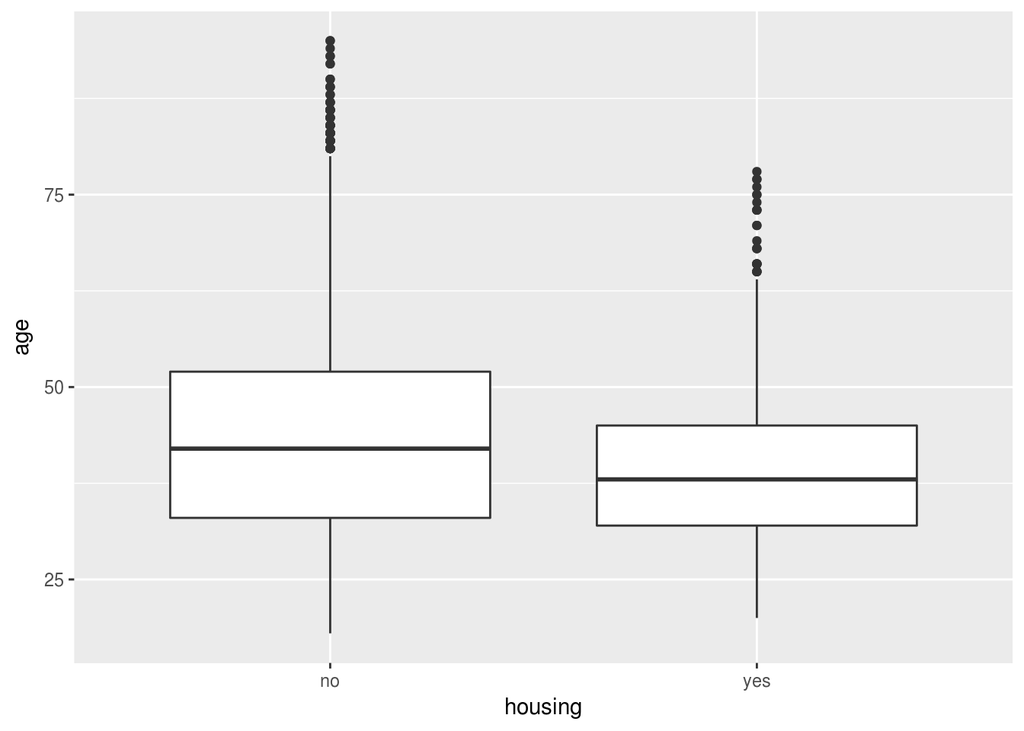

```r
desafioSemantix %>%
  ggplot(aes(x = housing, y = age)) +
  geom_boxplot()
```

```r
desafioSemantix %>%
  group_by(housing) %>%
  summarise(mean(age), median(age), quantile(age, 0.25), sd(age), quantile(age, 0.75))
```

```
## # A tibble: 2 x 6
##   housing `mean(age)` `median(age)` `quantile(age, … `sd(age)`
##   <fct>         <dbl>         <dbl>            <dbl>     <dbl>
## 1 no             43.1            42               33     12.1
## 2 yes            39.2            38               32      8.93
## # ... with 1 more variable: `quantile(age, 0.75)` <dbl>
```

```r
treeEmprestimoImobiliario = ctree(housing ~ marital + job + age + balance + education + default + loan, data = desafioSemantix, controls =  ctree_control(maxdepth = 4))
```

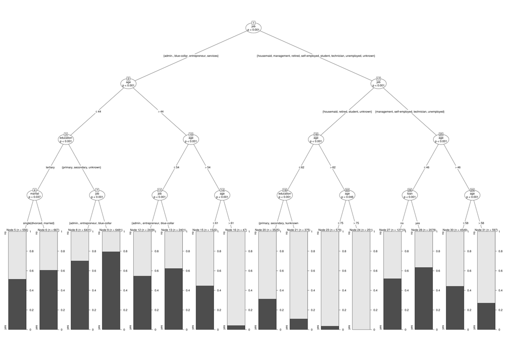

```r
plot(treeEmprestimoImobiliario)
```

- Olhando para as análises, podemos concluir que com chance de aproximadamente 0,8 de um cliente obter empréstimo imobiliário, tem-se como característica:
- Idade menor que 44 anos
- Educação primária, secundária ou desconhecida.
- Profissão ‘blue-collar’